# mvgam case study 1: model comparison and data assimilation

```r
mean(lynx_mgcv1_drps[,2])
```

```
## [1] 0.7
```

For the second `mgcv` model

```r
sum(lynx_mgcv2_drps[,1])
```

```
## [1] 2039.512
```

```r
mean(lynx_mgcv2_drps[,2])
```

```
## [1] 0
```

And for the `mvgam` model

```r
sum(lynx_mvgam_drps[,1])
```

```
## [1] 1071.031
```

```r
mean(lynx_mvgam_drps[,2])
```

```
## [1] 1
```

The `mvgam` has much more realistic uncertainty than the `mgcv` versions above. Of course this is just one out of sample comparison, and to really determine which model is most appropriate for forecasting we would want to run many of these tests using a [rolling window approach](https://robjhyndman.com/hyndsight/tscv/). Have a look at this model’s summary to see what is being estimated (note that longer MCMC runs would probably be needed to increase effective sample sizes)

```r
summary(lynx_mvgam)
```

```
## GAM formula:
```

```
## population ~ s(season, bs = "cc", k = 15)
```

```
## Family:
```

```
## poisson
```

```
## Link function:
```

```
## log
```

```
## Trend model:
```

```
## AR2
```

```
## N series:
```

```
## 1
```

```
## N observations:
```

```
## 40
```

```
## Status:
```

```
## Fitted using Stan
```

```
## GAM coefficient (beta) estimates:
```

```
##                    2.5%        50%      97.5% Rhat n.eff
## (Intercept)   6.7464093  6.7741950  6.7991423 1.00  2308
## s(season).1  -1.0815407 -0.3297185  0.5199864 1.00   863
## s(season).2  -0.1966502  0.6856240  1.6138847 1.00  1002
## s(season).3   0.2214496  1.3631150  2.3031000 1.00   728
## s(season).4   0.3719960  1.6808850  2.7048403 1.00   663
## s(season).5  -0.1813021  0.8440175  1.9174927 1.00   969
## s(season).6  -1.2837950 -0.3428520  0.9619480 1.00   739
## s(season).7  -1.5492080 -0.5492380  0.7953802 1.00   530
## s(season).8  -1.1122063 -0.1339095  1.0218917 1.00   887
## s(season).9  -0.3726991  0.8032935  1.7198552 1.00   773
## s(season).10 -0.3582353  1.0594850  2.1175650 1.00   578
## s(season).11 -0.6025266  0.5854940  1.5630752 1.00   572
## s(season).12 -1.1870035 -0.4613395  0.2246130 1.00   867
## s(season).13 -1.5019207 -0.8985030 -0.2054500 1.01   753
```

```
## GAM smoothing parameter (rho) estimates:
```

```
##               2.5%      50%    97.5% Rhat n.eff
## s(season) 2.532317 3.504915 4.261612    1  1209
```

```
## Latent trend parameter estimates:
```

```
##                2.5%        50%      97.5% Rhat n.eff
## ar1[1]    0.6350617  1.0803350 1.46110125    1   530
## ar2[1]   -0.7902456 -0.3466500 0.07497309    1   441
## sigma[1]  0.3695672  0.4727375 0.62711495    1  1059
```

```
## Stan MCMC diagnostics
```

```
## n_eff / iter looks reasonable for all parameters
## Rhat looks reasonable for all parameters
## 0 of 2000 iterations ended with a divergence (0%)
## 0 of 2000 iterations saturated the maximum tree depth of 12 (0%)
## E-FMI indicated no pathological behavior
```

Now inspect each model’s estimated smooth for the 19-year cyclic pattern. Note that the `mvgam` smooth plot is on a different scale compared to the `mgcv` plot, but interpretation is similar. The `mgcv` smooth is much wigglier, likely because it is compensating for any remaining autocorrelation not captured by the lag smooths. We could probably remedy this by reducing `k` in the seasonal smooth for the `mgcv` model (in practice this works well, but leaving `k` larger for the `mvgam`’s seasonal smooth is recommended as our experience is that this tends to lead to better performance and convergence)

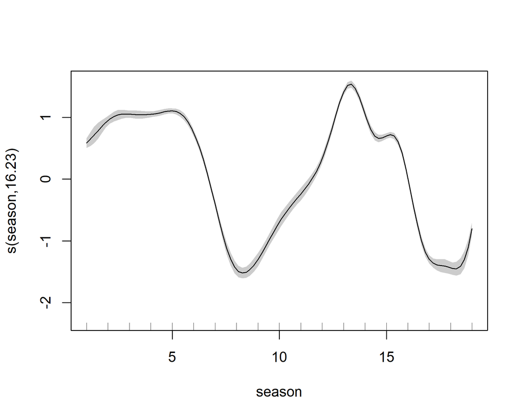

```r
plot(lynx_mgcv, select=1, shade=T)
```